# 이혜진_team_project

## 파일 출처

- FAO 식량가격지수 : https://www.fao.org/home/en/ (FAO 홈페이지)
- 곡물자급률 : 농림축산식품부 공공데이터

## 주제 : 식량가격지수로 보는 전쟁이 우리나라에 미치는 영향 분석

# (1) 유엔 식량농업기구(FAO) 세계 식량가격지수로 보는 전쟁 이후 현상황

```python
# 모듈 로딩
import pandas as pd
import matplotlib.pyplot as plt

# DF 불러오기
foodDF = pd.read_csv('Food_price_indices_data_jul825.csv', encoding = 'utf-8', header=[2])

# 데이터 확인
foodDF.info()
```

```
<class 'pandas.core.frame.DataFrame'>
RangeIndex: 391 entries, 0 to 390
Data columns (total 7 columns):
 #   Column            Non-Null Count  Dtype
---  ------            --------------  -----
 0   Date              390 non-null    object
 1   Food Price Index  390 non-null    float64
 2   Meat              390 non-null    float64
 3   Dairy             390 non-null    float64
 4   Cereals           390 non-null    float64
 5   Oils              390 non-null    float64
 6   Sugar             390 non-null    float64
dtypes: float64(6), object(1)
memory usage: 21.5+ KB
```

```python
foodDF.head()
```

|  | Date | Food Price Index | Meat | Dairy | Cereals | Oils | Sugar |
| --- | --- | --- | --- | --- | --- | --- | --- |
| 0 | NaN | NaN | NaN | NaN | NaN | NaN | NaN |
| 1 | Jan-90 | 64.1 | 73.4 | 53.5 | 64.1 | 44.59 | 87.9 |
| 2 | Feb-90 | 64.5 | 76.0 | 52.2 | 62.2 | 44.50 | 90.7 |
| 3 | Mar-90 | 63.8 | 77.8 | 41.4 | 61.3 | 45.75 | 95.1 |
| 4 | Apr-90 | 65.8 | 80.4 | 48.4 | 62.8 | 44.02 | 94.3 |

```python
# 0번째 필요 없는 행 제거
#foodDF.drop(0, axis=0, inplace=True)
```

```python
# Date 컬럼으로 인덱스 지정
foodDF.set_index('Date')
```

| Date | Food Price Index | Meat | Dairy | Cereals | Oils | Sugar |
| --- | --- | --- | --- | --- | --- | --- |
| NaN | NaN | NaN | NaN | NaN | NaN | NaN |
| Jan-90 | 64.1 | 73.4 | 53.5 | 64.1 | 44.59 | 87.9 |
| Feb-90 | 64.5 | 76.0 | 52.2 | 62.2 | 44.50 | 90.7 |
| Mar-90 | 63.8 | 77.8 | 41.4 | 61.3 | 45.75 | 95.1 |
| Apr-90 | 65.8 | 80.4 | 48.4 | 62.8 | 44.02 | 94.3 |
| ... | ... | ... | ... | ... | ... | ... |
| 22-Feb | 141.1 | 113.4 | 141.5 | 145.3 | 201.70 | 110.5 |
| 22-Mar | 159.7 | 119.3 | 145.8 | 170.1 | 251.80 | 117.9 |
| 22-Apr | 158.4 | 121.9 | 146.7 | 169.7 | 237.50 | 121.5 |
| 22-May | 157.9 | 122.7 | 143.9 | 173.5 | 229.20 | 120.4 |
| 22-Jun | 154.2 | 124.7 | 149.8 | 166.3 | 211.80 | 117.3 |

391 rows × 6 columns

```python
# 필요한 행만 출력(2021년 1월 이후)
foodDF = foodDF.iloc[373:]
foodDF
```

|  | Date | Food Price Index | Meat | Dairy | Cereals | Oils | Sugar |
| --- | --- | --- | --- | --- | --- | --- | --- |
| 373 | 21-Jan | 113.5 | 96.0 | 111.2 | 125.0 | 138.87 | 94.2 |
| 374 | 21-Feb | 116.6 | 97.8 | 113.1 | 126.1 | 147.46 | 100.2 |
| 375 | 21-Mar | 119.2 | 100.8 | 117.5 | 123.9 | 159.30 | 96.2 |
| 376 | 21-Apr | 122.1 | 104.3 | 119.1 | 126.2 | 162.19 | 100.0 |
| 377 | 21-May | 128.1 | 107.4 | 121.1 | 133.7 | 174.90 | 106.8 |
| 378 | 21-Jun | 125.3 | 110.7 | 119.9 | 130.3 | 157.70 | 107.7 |
| 379 | 21-Jul | 124.6 | 114.1 | 116.7 | 126.3 | 155.50 | 109.6 |
| 380 | 21-Aug | 128.0 | 113.4 | 116.2 | 130.4 | 165.90 | 120.5 |
| 381 | 21-Sep | 129.2 | 112.7 | 118.1 | 132.8 | 168.60 | 121.2 |
| 382 | 21-Oct | 133.2 | 112.0 | 121.5 | 137.1 | 184.80 | 119.1 |
| 383 | 21-Nov | 135.3 | 112.5 | 126.0 | 141.4 | 184.60 | 120.2 |
| 384 | 21-Dec | 133.7 | 111.0 | 129.0 | 140.5 | 178.50 | 116.4 |
| 385 | 22-Jan | 135.6 | 112.1 | 132.6 | 140.6 | 185.90 | 112.7 |
| 386 | 22-Feb | 141.1 | 113.4 | 141.5 | 145.3 | 201.70 | 110.5 |
| 387 | 22-Mar | 159.7 | 119.3 | 145.8 | 170.1 | 251.80 | 117.9 |
| 388 | 22-Apr | 158.4 | 121.9 | 146.7 | 169.7 | 237.50 | 121.5 |
| 389 | 22-May | 157.9 | 122.7 | 143.9 | 173.5 | 229.20 | 120.4 |
| 390 | 22-Jun | 154.2 | 124.7 | 149.8 | 166.3 | 211.80 | 117.3 |

```python
date_DF = foodDF['Date']
price_DF = foodDF['Food Price Index']
meat_DF = foodDF['Meat']
dairy_DF = foodDF['Dairy']
Cereals_DF = foodDF['Cereals']
oils_DF = foodDF['Oils']
sugar_DF = foodDF['Sugar']
```

```python
x_values = date_DF
y_values_1 = price_DF
y_values_2 = meat_DF
y_values_3 = dairy_DF
y_values_4 = Cereals_DF
y_values_5 = oils_DF
y_values_6 = sugar_DF
```

```python
import matplotlib
from matplotlib import font_manager,rc  #한글 폰트 입력을 위한 라이브러리
import matplotlib.pyplot as plt   #그래프 그리기 위한 라이브러리
```

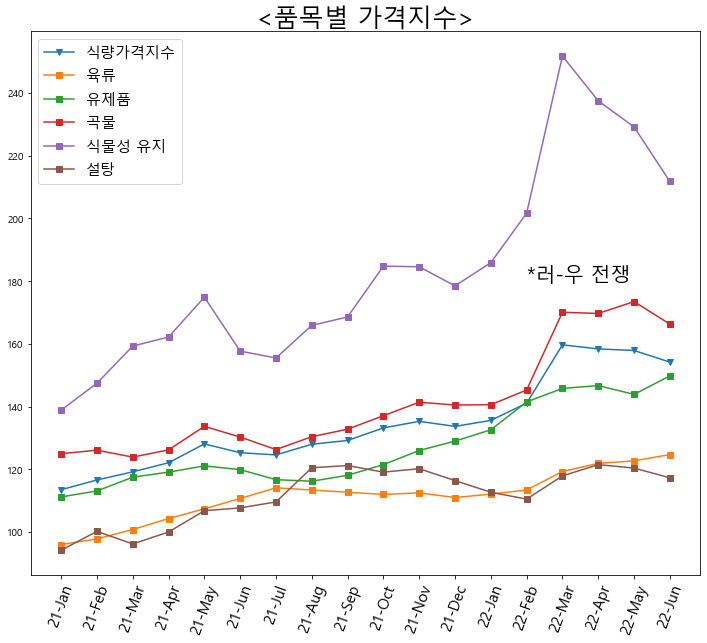

```python
fig = plt.figure(figsize=(12, 10))
plt.rc('font',family='Malgun Gothic')
plt.plot(x_values, y_values_1, marker='v', )
plt.plot(x_values, y_values_2, marker='s')
plt.plot(x_values, y_values_3, marker='s')
plt.plot(x_values, y_values_4, marker='s')
plt.plot(x_values, y_values_5, marker='s')
plt.plot(x_values, y_values_6, marker='s')
plt.legend(('식량가격지수','육류','유제품','곡물','식물성 유지','설탕'),fontsize=15)
plt.title('<품목별 가격지수>', size=25)
plt.xticks(rotation=70, size=15)
plt.text(x=13, y = 180 ,s='*러-우 전쟁', color = 'black', fontsize = 20)

plt.show()
```

### 식품업계는 대부분 원료를 비축해두고 쓰기 때문에 원재료 가격 상승 영향은 3∼6개월 시차를 두고 나타남. 이런 상황에서 원/달러 환율이 1300원대로 폭등하면서 하반기에 수입 물가는 더 오를 예정.

# (2) 그렇다면 곡물 가격지수는..?

## (부제 : 위기의 곡물자급률, 느슨해진 우리나라 농업에 긴장 심기)

```python
# DF 불러오기
selfDF = pd.read_csv('곡물자급률(1957~2020).csv', encoding = 'euc_kr')

# 데이터 확인
selfDF.info()
```

```
<class 'pandas.core.frame.DataFrame'>
RangeIndex: 64 entries, 0 to 63
Data columns (total 8 columns):
 #   Column  Non-Null Count  Dtype
---  ------  --------------  -----
 0   연도      64 non-null     object
 1   전 체     64 non-null     float64
 2   보리쌀     64 non-null     float64
 3   밀       64 non-null     float64
 4   옥수수     64 non-null     float64
 5   콩       64 non-null     float64
 6   서 류     64 non-null     float64
 7   기 타     64 non-null     float64
dtypes: float64(7), object(1)
memory usage: 4.1+ KB
```

```python
selfDF.head()
```

|  | 연도 | 전 체 | 보리쌀 | 밀 | 옥수수 | 콩 | 서 류 | 기 타 |
| --- | --- | --- | --- | --- | --- | --- | --- | --- |
| 0 | ’57 | 83.1 | 85.4 | 25.3 | 23.4 | 82.3 | 100.0 | 100.0 |
| 1 | ’58 | 82.4 | 72.4 | 21.5 | 86.9 | 70.2 | 100.0 | 100.0 |
| 2 | ’59 | 97.0 | 114.2 | 38.5 | 34.1 | 84.1 | 100.0 | 100.0 |
| 3 | ’60 | 94.5 | 110.4 | 33.9 | 18.9 | 79.3 | 100.0 | 100.0 |
| 4 | ’61 | 91.1 | 90.2 | 39.8 | 20.0 | 87.8 | 100.0 | 100.0 |

```python
# 필요한 행만 출력(2016년~2020년, 최근 5년)
self2DF = selfDF.iloc[59:]
self2DF
```

|  | 연도 | 전 체 | 보리쌀 | 밀 | 옥수수 | 콩 | 서 류 | 기 타 |
| --- | --- | --- | --- | --- | --- | --- | --- | --- |
| 59 | ‘16 | 23.7 | 23.3 | 0.9 | 0.8 | 7.0 | 94.8 | 11.9 |
| 60 | ‘17 | 23.4 | 24.9 | 0.9 | 0.8 | 5.4 | 95.2 | 9.3 |
| 61 | ‘18 | 21.8 | 30.9 | 0.7 | 0.7 | 6.3 | 95.4 | 6.9 |
| 62 | ‘19 | 21.0 | 46.1 | 0.5 | 0.7 | 6.6 | 95.3 | 9.4 |
| 63 | ‘20 | 20.2 | 36.5 | 0.5 | 0.7 | 7.5 | 95.8 | 12.6 |

```python
self2DF['연도'] = [2016,2017,2018,2019,2020]
self2DF
```

|  | 연도 | 전 체 | 보리쌀 | 밀 | 옥수수 | 콩 | 서 류 | 기 타 |
| --- | --- | --- | --- | --- | --- | --- | --- | --- |
| 59 | 2016 | 23.7 | 23.3 | 0.9 | 0.8 | 7.0 | 94.8 | 11.9 |
| 60 | 2017 | 23.4 | 24.9 | 0.9 | 0.8 | 5.4 | 95.2 | 9.3 |
| 61 | 2018 | 21.8 | 30.9 | 0.7 | 0.7 | 6.3 | 95.4 | 6.9 |
| 62 | 2019 | 21.0 | 46.1 | 0.5 | 0.7 | 6.6 | 95.3 | 9.4 |
| 63 | 2020 | 20.2 | 36.5 | 0.5 | 0.7 | 7.5 | 95.8 | 12.6 |

```python
self2DF.set_index('연도')
self2DF
```

|  | 연도 | 전 체 | 보리쌀 | 밀 | 옥수수 | 콩 | 서 류 | 기 타 |
| --- | --- | --- | --- | --- | --- | --- | --- | --- |
| 59 | 2016 | 23.7 | 23.3 | 0.9 | 0.8 | 7.0 | 94.8 | 11.9 |
| 60 | 2017 | 23.4 | 24.9 | 0.9 | 0.8 | 5.4 | 95.2 | 9.3 |
| 61 | 2018 | 21.8 | 30.9 | 0.7 | 0.7 | 6.3 | 95.4 | 6.9 |
| 62 | 2019 | 21.0 | 46.1 | 0.5 | 0.7 | 6.6 | 95.3 | 9.4 |
| 63 | 2020 | 20.2 | 36.5 | 0.5 | 0.7 | 7.5 | 95.8 | 12.6 |

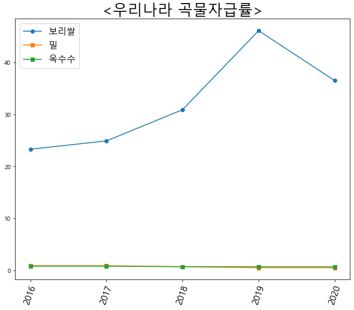

```python
fig = plt.figure(figsize=(10, 8))
plt.rc('font',family='Malgun Gothic')
plt.plot(self2DF['연도'], self2DF['보리쌀'], marker='o')
plt.plot(self2DF['연도'], self2DF['밀'], marker='s')
plt.plot(self2DF['연도'], self2DF['옥수수'], marker='s')

plt.legend(('보리쌀','밀','옥수수',),fontsize=15)
plt.title('<우리나라 곡물자급률>', size=25)
plt.xticks(range(2016,2021), rotation=70, size=15)

plt.show()
```

```python
self2DF
```

|  | 연도 | 전 체 | 보리쌀 | 밀 | 옥수수 | 콩 | 서 류 | 기 타 |
| --- | --- | --- | --- | --- | --- | --- | --- | --- |
| 59 | 2016 | 23.7 | 23.3 | 0.9 | 0.8 | 7.0 | 94.8 | 11.9 |
| 60 | 2017 | 23.4 | 24.9 | 0.9 | 0.8 | 5.4 | 95.2 | 9.3 |
| 61 | 2018 | 21.8 | 30.9 | 0.7 | 0.7 | 6.3 | 95.4 | 6.9 |
| 62 | 2019 | 21.0 | 46.1 | 0.5 | 0.7 | 6.6 | 95.3 | 9.4 |
| 63 | 2020 | 20.2 | 36.5 | 0.5 | 0.7 | 7.5 | 95.8 | 12.6 |

```python
# 정규화
d=[]
for col in self2DF.columns:
    c=[]
    for i in self2DF.index:
        c.append(round((self2DF.loc[i][col] - self2DF[col].mean()) / self2DF[col].std(), 2))
    d.append(c)
d
```

```
[[-1.26, -0.63, 0.0, 0.63, 1.26],
 [1.11, 0.91, -0.15, -0.68, -1.2],
 [-0.97, -0.8, -0.15, 1.48, 0.45],
 [1.0, 1.0, 0.0, -1.0, -1.0],
 [1.1, 1.1, -0.73, -0.73, -0.73],
 [0.56, -1.47, -0.33, 0.05, 1.19],
 [-1.39, -0.28, 0.28, 0.0, 1.39],
 [0.82, -0.32, -1.37, -0.27, 1.13]]
```

[figure not shown]

```python
d0=pd.Series(d[0])
d1=pd.Series(d[1])
d2=pd.Series(d[2])
d3=pd.Series(d[3])
d4=pd.Series(d[4])
d5=pd.Series(d[5])
d6=pd.Series(d[6])

plt.figure(figsize=(20,10))
plt.rcParams['axes.unicode_minus']=False
# 필요한 밀, 옥수수만
plt.plot(self2DF['연도'], d2,marker='o')
plt.plot(self2DF['연도'], d3,marker='o')
plt.xticks(range(2016,2021),size=20)
plt.legend(('밀','옥수수',),fontsize=15)
plt.title("<밀, 옥수수 곡물자급률>",size=20)

plt.show()
```

### 연도별 곡물자급률

```python
selfDF
```

|  | 연도 | 전 체 | 보리쌀 | 밀 | 옥수수 | 콩 | 서 류 | 기 타 |
| --- | --- | --- | --- | --- | --- | --- | --- | --- |
| 0 | ’57 | 83.1 | 85.4 | 25.3 | 23.4 | 82.3 | 100.0 | 100.0 |
| 1 | ’58 | 82.4 | 72.4 | 21.5 | 86.9 | 70.2 | 100.0 | 100.0 |
| 2 | ’59 | 97.0 | 114.2 | 38.5 | 34.1 | 84.1 | 100.0 | 100.0 |
| 3 | ’60 | 94.5 | 110.4 | 33.9 | 18.9 | 79.3 | 100.0 | 100.0 |
| 4 | ’61 | 91.1 | 90.2 | 39.8 | 20.0 | 87.8 | 100.0 | 100.0 |
| ... | ... | ... | ... | ... | ... | ... | ... | ... |
| 59 | ‘16 | 23.7 | 23.3 | 0.9 | 0.8 | 7.0 | 94.8 | 11.9 |
| 60 | ‘17 | 23.4 | 24.9 | 0.9 | 0.8 | 5.4 | 95.2 | 9.3 |
| 61 | ‘18 | 21.8 | 30.9 | 0.7 | 0.7 | 6.3 | 95.4 | 6.9 |
| 62 | ‘19 | 21.0 | 46.1 | 0.5 | 0.7 | 6.6 | 95.3 | 9.4 |
| 63 | ‘20 | 20.2 | 36.5 | 0.5 | 0.7 | 7.5 | 95.8 | 12.6 |

64 rows × 8 columns

```python
year = []
for i in range(64):
    year.append(selfDF['연도'][i][1]+"0년대")
print(year)
```

[output not shown]

```python
selfDF['year'] = year
selfDF
```

|  | 연도 | 전 체 | 보리쌀 | 밀 | 옥수수 | 콩 | 서 류 | 기 타 | year |
| --- | --- | --- | --- | --- | --- | --- | --- | --- | --- |
| 0 | ’57 | 83.1 | 85.4 | 25.3 | 23.4 | 82.3 | 100.0 | 100.0 | 50년대 |
| 1 | ’58 | 82.4 | 72.4 | 21.5 | 86.9 | 70.2 | 100.0 | 100.0 | 50년대 |
| 2 | ’59 | 97.0 | 114.2 | 38.5 | 34.1 | 84.1 | 100.0 | 100.0 | 50년대 |
| 3 | ’60 | 94.5 | 110.4 | 33.9 | 18.9 | 79.3 | 100.0 | 100.0 | 60년대 |
| 4 | ’61 | 91.1 | 90.2 | 39.8 | 20.0 | 87.8 | 100.0 | 100.0 | 60년대 |
| ... | ... | ... | ... | ... | ... | ... | ... | ... | ... |
| 59 | ‘16 | 23.7 | 23.3 | 0.9 | 0.8 | 7.0 | 94.8 | 11.9 | 10년대 |
| 60 | ‘17 | 23.4 | 24.9 | 0.9 | 0.8 | 5.4 | 95.2 | 9.3 | 10년대 |
| 61 | ‘18 | 21.8 | 30.9 | 0.7 | 0.7 | 6.3 | 95.4 | 6.9 | 10년대 |
| 62 | ‘19 | 21.0 | 46.1 | 0.5 | 0.7 | 6.6 | 95.3 | 9.4 | 10년대 |
| 63 | ‘20 | 20.2 | 36.5 | 0.5 | 0.7 | 7.5 | 95.8 | 12.6 | 20년대 |

64 rows × 9 columns

```python
groupDF = selfDF.groupby('year').mean()
groupDF
```

| year | 전 체 | 보리쌀 | 밀 | 옥수수 | 콩 | 서 류 | 기 타 |
| --- | --- | --- | --- | --- | --- | --- | --- |
| 00년대 | 28.80 | 52.170000 | 0.260000 | 0.860000 | 8.920000 | 98.52 | 9.53 |
| 10년대 | 23.67 | 25.490000 | 0.730000 | 0.830000 | 8.420000 | 95.91 | 10.03 |
| 20년대 | 20.20 | 36.500000 | 0.500000 | 0.700000 | 7.500000 | 95.80 | 12.60 |
| 50년대 | 87.50 | 90.666667 | 28.433333 | 48.133333 | 78.866667 | 100.00 | 100.00 |
| 60년대 | 87.57 | 97.550000 | 24.680000 | 30.860000 | 91.800000 | 100.00 | 99.57 |
| 70년대 | 70.68 | 93.310000 | 6.170000 | 10.460000 | 74.390000 | 99.98 | 98.98 |
| 80년대 | 46.75 | 90.770000 | 1.840000 | 3.720000 | 23.890000 | 99.57 | 36.29 |
| 90년대 | 32.33 | 69.390000 | 0.125000 | 1.300000 | 12.500000 | 98.36 | 10.80 |

```python
# 50년대부터 나오게 만들기
finalDF = groupDF.reindex(list(groupDF.index[3:])+list(groupDF.index[:3]))
```

```python
finalDF
```

| year | 전 체 | 보리쌀 | 밀 | 옥수수 | 콩 | 서 류 | 기 타 |
| --- | --- | --- | --- | --- | --- | --- | --- |
| 50년대 | 87.50 | 90.666667 | 28.433333 | 48.133333 | 78.866667 | 100.00 | 100.00 |
| 60년대 | 87.57 | 97.550000 | 24.680000 | 30.860000 | 91.800000 | 100.00 | 99.57 |
| 70년대 | 70.68 | 93.310000 | 6.170000 | 10.460000 | 74.390000 | 99.98 | 98.98 |
| 80년대 | 46.75 | 90.770000 | 1.840000 | 3.720000 | 23.890000 | 99.57 | 36.29 |
| 90년대 | 32.33 | 69.390000 | 0.125000 | 1.300000 | 12.500000 | 98.36 | 10.80 |
| 00년대 | 28.80 | 52.170000 | 0.260000 | 0.860000 | 8.920000 | 98.52 | 9.53 |
| 10년대 | 23.67 | 25.490000 | 0.730000 | 0.830000 | 8.420000 | 95.91 | 10.03 |
| 20년대 | 20.20 | 36.500000 | 0.500000 | 0.700000 | 7.500000 | 95.80 | 12.60 |

[output not shown]

```
<BarContainer object of 7 artists>
```

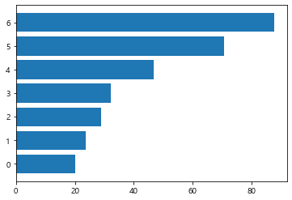

```python
value_list = []
for i in range(7, 0, -1):
    value_list.append(finalDF.iloc[i, 0])
    #print(value_list)

plt.barh(y, value_list)
```

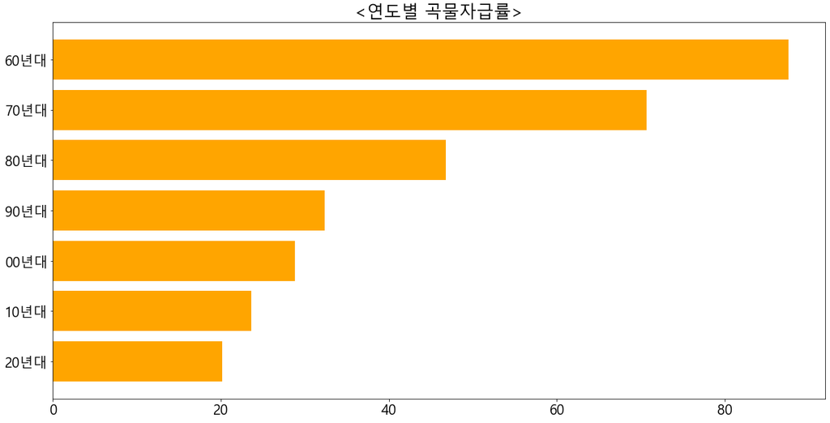

```python
import matplotlib.pyplot as plt
import numpy as np

y = np.arange(7)
years = ['20년대','10년대','00년대','90년대','80년대','70년대','60년대']
values = finalDF['전 체']

plt.figure(figsize=(20,10))
plt.barh(y, value_list , linewidth = 5, color = 'orange')

plt.yticks(y, years, size= 20)
plt.xticks(size=20)
plt.title("<연도별 곡물자급률>", size = 25)
#plt.text(x=13, y = 180 ,s='', color = 'black', fontsize = 20)

plt.show()
```

### 최종 결론 및 해결 방안 :

(1) 개인적 해결방안 : 팜유 세계 최대 수출국이면서도 식용유 품귀현상을 겪는 인도네시아에서는 '식용유 없이 요리하는 법' 시연회를 개최하는 등 튀기지 말고 끓이거나 쪄서 먹자는 캠페인을 벌이고 있다. 우리나라도 가정에서는 튀거나 볶는 음식 대신 찌거나 삶는 음식을 먹는 캠페인을 유도해야 한다.

(2) 국가적 해결방안 : 우리나라는 세계식량안보 지수 순위가 OECD 국가 중 최하위권에 속하기 때문에 국가에서 법적으로 구속해야한다는 의견. 전쟁 뿐만 아니라 기후 위기로 인해 자급자족에 대한 위기가 더욱 심화되고 있기 때문이다. 우리랑 비슷한 순위에 있는 일본은 국가에서 지급가능한 곡물을 늘리기 위해 논을 밀 경작지로 전환하는 정책을 보였다. 그래도 일본은 미국에 곡물회사를 가지고 있어 우리나라보다 더 나은 상황이라고 볼 수 있다. 우리나라도 국내에 버려지는 농지를 활용하는 방법을 찾거나, 해외 식량공급망 확보에 주의를 기울여야한다.